# Bioclim y Maxent

Julián A. Velasco

29 de julio de 2018

Vamos a generar modelos usando dos algoritmos -Bioclim y Maxent-

Primero subimos nuestros datos de coordenadas:

```r
library(rgdal)
library(sp)
library(raster)
library(rgeos)
library(dismo)


coords <- read.csv("Coordenadas_GBIF_depuradas.csv")
head(coords)
```

```
##    X Longitude Latitude
## 1  5 -100.7055 22.49427
## 2 19 -101.0598 22.71030
## 3 20 -101.5221 26.31369
## 4 26 -105.9166 28.65161
## 5 65 -104.8663 26.89161
## 6 66 -100.9707 22.16421
```

Le quitamos la primera columna, no la necesitamos

```r
coords <- coords[,c(2:3)]
head(coords)
```

```
##   Longitude Latitude
## 1 -100.7055 22.49427
## 2 -101.0598 22.71030
## 3 -101.5221 26.31369
## 4 -105.9166 28.65161
## 5 -104.8663 26.89161
## 6 -100.9707 22.16421
```

Subimos las capas climáticas

```r
clim.act <- list.files("C:/Users/juvel/Dropbox/Cursos_Charlas/Zaragosa_2018/Curso_FES_Zaragosa18/Capas_clima/", pattern="asc", full.names=T)
clim.act <- stack(clim.act) # hacemos un stack

clim.act
```

```
## class       : RasterStack
## dimensions  : 2183, 3799, 8293217, 19  (nrow, ncol, ncell, nlayers)
## resolution  : 0.008333334, 0.008333334  (x, y)
## extent      : -118.3684, -86.71002, 14.5296, 32.72126  (xmin, xmax, ymin, ymax)
## coord. ref. : NA
## names       : bio1, bio10, bio11, bio12, bio13, bio14, bio15, bio16, bio17, bio18, bio19, bio2, bio3, bio4, bio5, ...
```

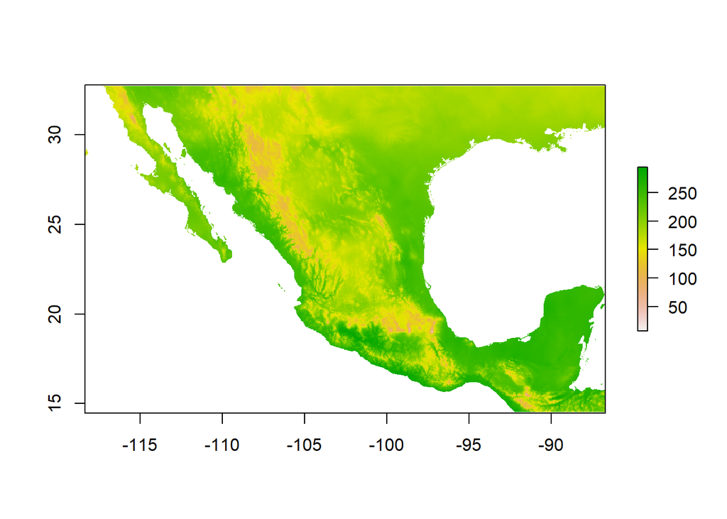

```r
plot(clim.act[[1]])
```

Vamos a hacer un buffer a nuestros puntos. Este buffer será nuestra área M del Diagrama BAM y es el área que la especie hipóteticamente ha podido “explorar” durante su historia evolutiva (i.e., dispersión, colonización, extinción):

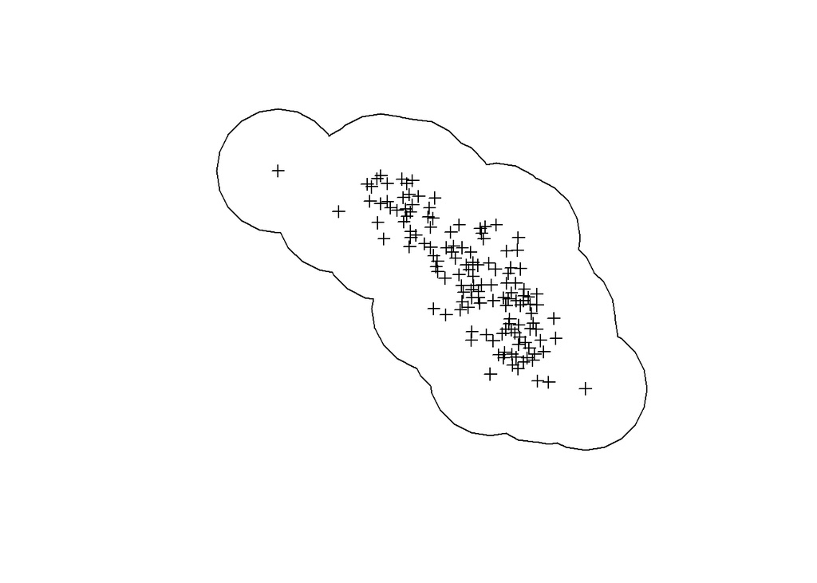

```r
coordinates(coords) <- ~Longitude+Latitude

library(rgeos)
buffer.sp <- gBuffer(coords, byid=FALSE, id=NULL, width=3.0, quadsegs=5,
                     capStyle="ROUND", joinStyle="ROUND", mitreLimit=1.0)

plot(buffer.sp)
plot(coords, add=TRUE)
```

Vamos a cortar las capas climáticas usando este buffer

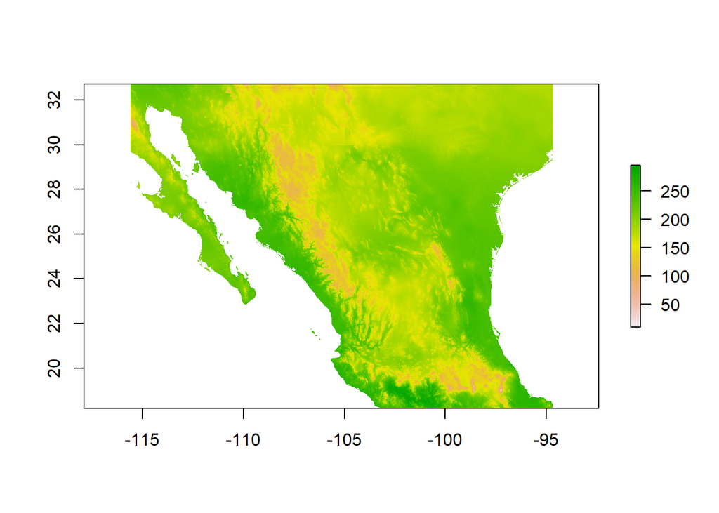

```r
# Usaremos mask, puede tardar un poco, así que tengan un poco de paciencia.
clim.m <- crop(clim.act, buffer.sp)
plot(clim.m[[1]])
```

Ahora vamos a calibrar el modelo usando el algoritmo Bioclim

```r
# primero convertimos las coordenadas a dataframe

coordsDF <- as.data.frame(coords)

bioc.modesta <- bioclim(clim.m, coordsDF)
```

Vamos a ver las gráficas de las variables de respuesta

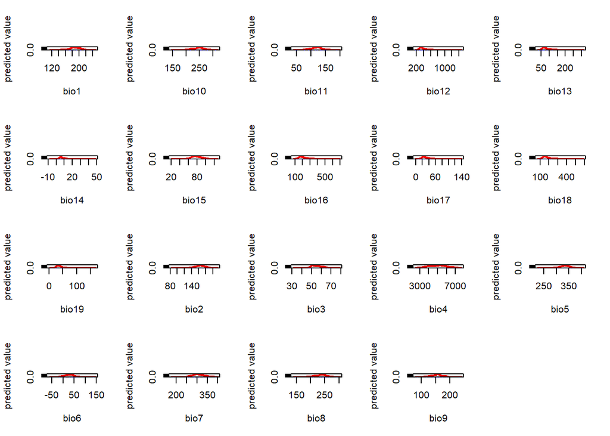

```r
response(bioc.modesta)
```

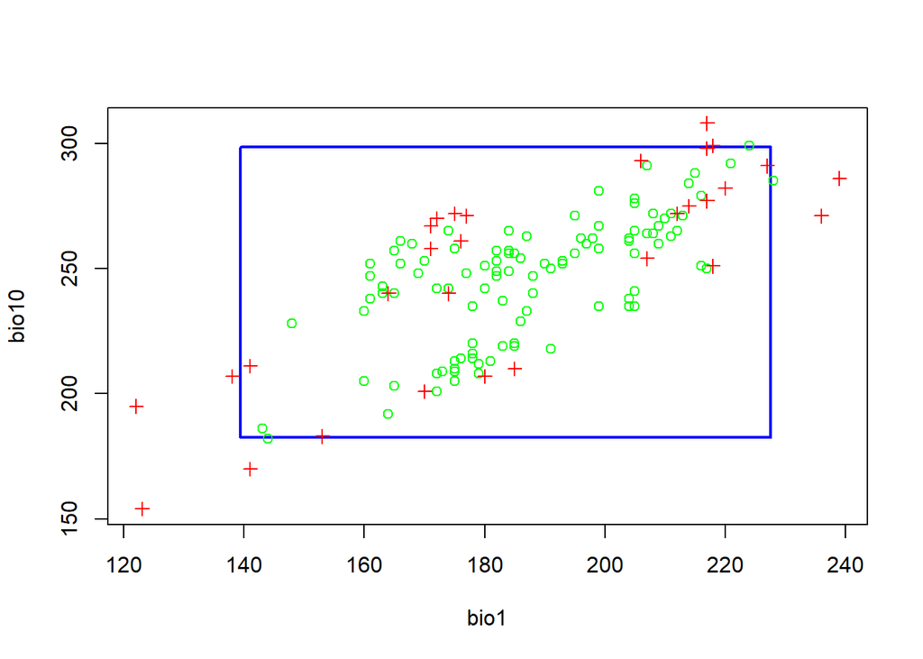

```r
plot(bioc.modesta, a=1, b=2, p=0.95)
```

Ahora vamos a generar la predicción geográfica:

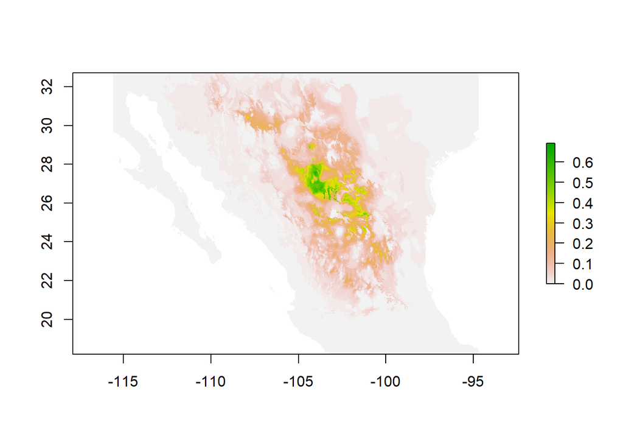

```r
pred.bioc <- predict(clim.m, bioc.modesta)

plot(pred.bioc) # graficamos
```

Vamos a generar una predicción binaria (0 ó 1; presencia vs. ausencia). Usaremos el criterio de umbral del “minimum presence training”

```r
coords.bioc <- extract(pred.bioc, coords)
head(coords.bioc)
```

```
## [1] 0.12408759 0.00729927 0.30656934 0.18248175 0.15328467 0.03649635
```

```r
a <- min(coords.bioc)
a
```

```
## [1] 0.00729927
```

Usaremos ese valor para generar la predicción binaria. Por encima de 0.0073 será presencia y por debajo, ausencia.

```r
bin.bioc <- reclassify(pred.bioc,c(-Inf,a,0, a,Inf,1))
bin.bioc
```

```
## class       : RasterLayer
## dimensions  : 1742, 2509, 4370678  (nrow, ncol, ncell)
## resolution  : 0.008333334, 0.008333334  (x, y)
## extent      : -115.61, -94.70169, 18.2046, 32.72126  (xmin, xmax, ymin, ymax)
## coord. ref. : NA
## data source : in memory
## names       : layer
## values      : 0, 1  (min, max)
```

Graficamos

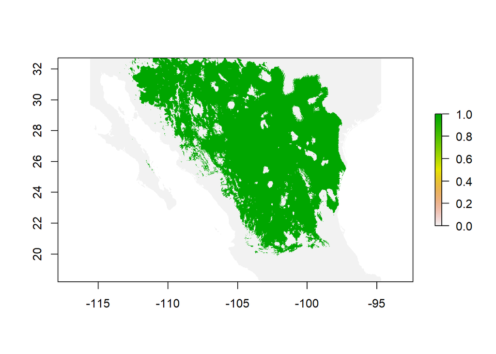

```r
plot(bin.bioc)
```

Vemos que la predicción geográfica ocupa una gran parte del área que se usó para calibrar (entorno, M, background). Es necesario probar con un entorno quizás más grande (valores de 5 ó 6 en el buffer que se hizo para cortar las capas). Pero vamos a hacer el mismo modelo usando la extensión completa de las capas.

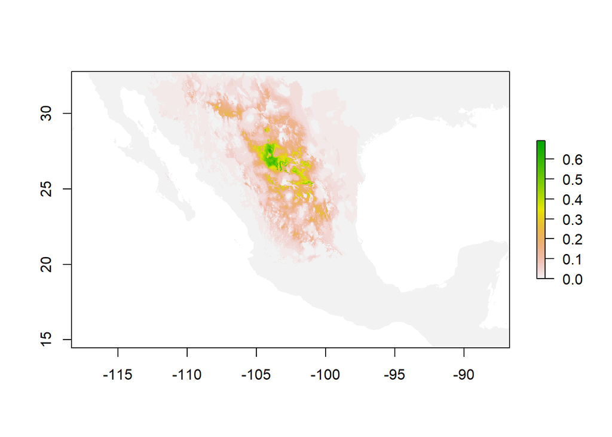

```r
bioc.modesta.v2 <- bioclim(clim.act, coordsDF)
pred.bioc.v2 <- predict(clim.act, bioc.modesta.v2)
plot(pred.bioc.v2)
```

Comparemos las dos predicciones:

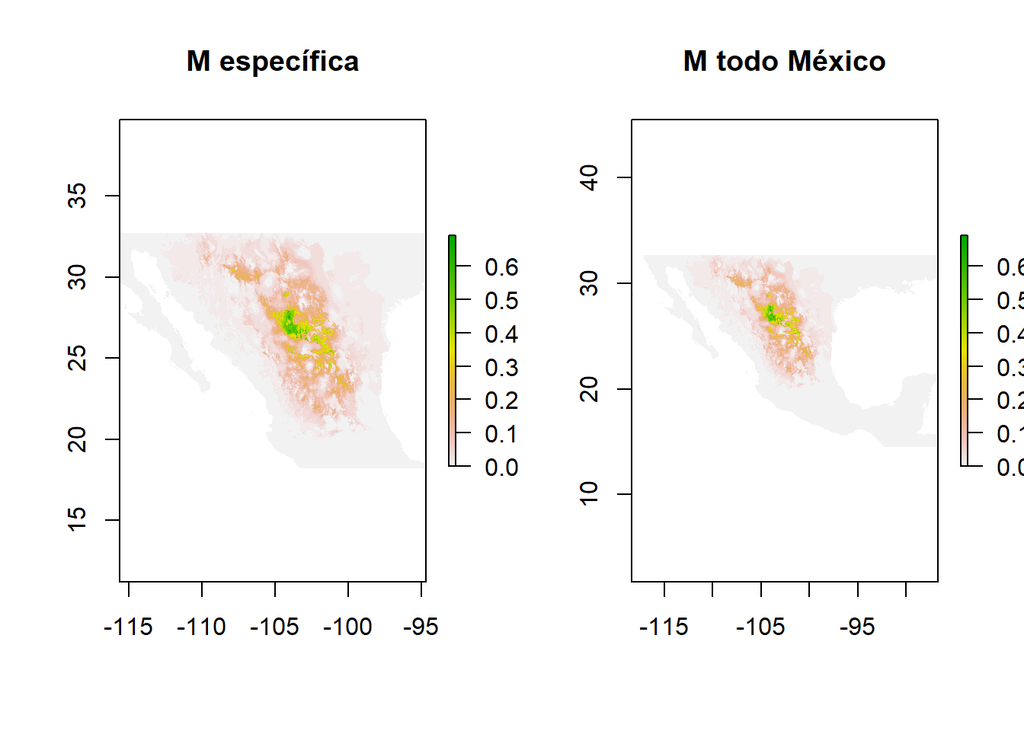

```r
par(mfrow=c(1,2))
plot(pred.bioc, main="M específica")
plot(pred.bioc.v2, main="M todo México")
```

Aquí hemos calibrado un modelo de nicho ecológico usando todos los datos disponibles y por lo tanto no tenemos forma de evaluar que tanto error puede tener nuestra predicción geográfica. Vamos a partir los datos en dos conjuntos. Uno de calibración y uno de validación:

La partición de los datos será aleatoria. Usaremos la función `kfold` para esto. Usaremos 5 grupos

```r
group <- kfold(coordsDF, 5)
group
```

```
##   [1] 5 4 3 1 4 4 3 1 4 2 4 3 2 3 1 2 1 5 2 4 1 4 5 2 5 3 3 3 5 5 4 5 4 4 1
##  [36] 2 3 3 1 5 5 4 5 5 1 2 4 5 4 4 1 3 2 4 3 5 2 3 4 1 1 5 1 2 3 2 1 3 5 1
##  [71] 2 4 1 2 5 2 5 1 1 3 3 4 2 2 3 3 2 3 1 1 1 4 3 2 3 4 4 4 2 4 5 1 5 5 3
## [106] 3 3 2 5 5 3 4 4 2 2 5 5 1 2 4 1 3 1 2 1 1 2 4 2 2 2 1 5 5 5 4 3
```

```r
length(group)
```

```
## [1] 137
```

```r
pres_train <- coordsDF[group != 1, ]
pres_test <- coordsDF[group == 1, ]

pres_train
```

```
##      Longitude Latitude
## 1   -100.70555 22.49427
## 2   -101.05979 22.71030
## 3   -101.52213 26.31369
## 5   -104.86634 26.89161
## 6   -100.97070 22.16421
## 7   -101.00324 27.92715
## 9   -100.23816 24.36905
## 10  -101.10850 23.89352
## 11  -100.84574 25.24488
## 12  -100.66156 26.03307
## 13  -100.88555 23.68940
## 14  -105.00584 30.46371
## 16  -101.89417 22.83517
## 18  -102.62886 28.46958
```

[output cut: 96 more lines]

```r
pres_test
```

```
##      Longitude Latitude
## 4   -105.91661 28.65161
## 8    -99.12439 23.64901
## 15  -101.71500 23.85833
## 17  -105.05407 27.65698
## 21  -102.91481 27.19092
## 35  -107.15242 29.98267
## 39  -104.09783 28.11419
## 45  -106.08064 31.30008
## 51  -106.58603 31.37706
## 60  -100.38000 24.09300
## 61  -105.05944 25.07444
## 63  -103.83600 26.73600
## 67  -105.19697 28.04955
## 70  -100.32000 24.84600
## 73  -100.03250 25.24306
## 78  -106.82972 29.86667
## 79  -100.60167 23.43936
## 89  -100.38333 25.28378
## 90  -100.94389 23.34583
## 91  -102.06314 26.98422
## 102 -101.32361 27.06750
## 118 -102.30833 21.90833
## 121 -102.80833 25.34167
## 123 -103.81958 29.15542
## 125 -106.17783 28.84009
## 126 -101.44167 26.79167
## 132  -99.47500 21.50833
```

Ya tenemos las presencias particionadas en dos conjuntos (calibración o “training” y validación y “testing”). Para validar nuestros modelos necesitamos a fuerza ausencias. No tenemos ausencias, así que vamos a generar unas ausencias aleatorias a partir de la geografía: a este tipo de ausencias se les conoce como “pseudo-ausencias”

```r
ext <- extent(clim.m)
backg <- randomPoints(clim.m, n=1000, ext=ext)
colnames(backg) = c('Longitude', 'Latitude')
group <- kfold(backg, 5)
backg_train <- backg[group != 1, ]
backg_test <- backg[group == 1, ]
```

Vamos a graficar los puntos

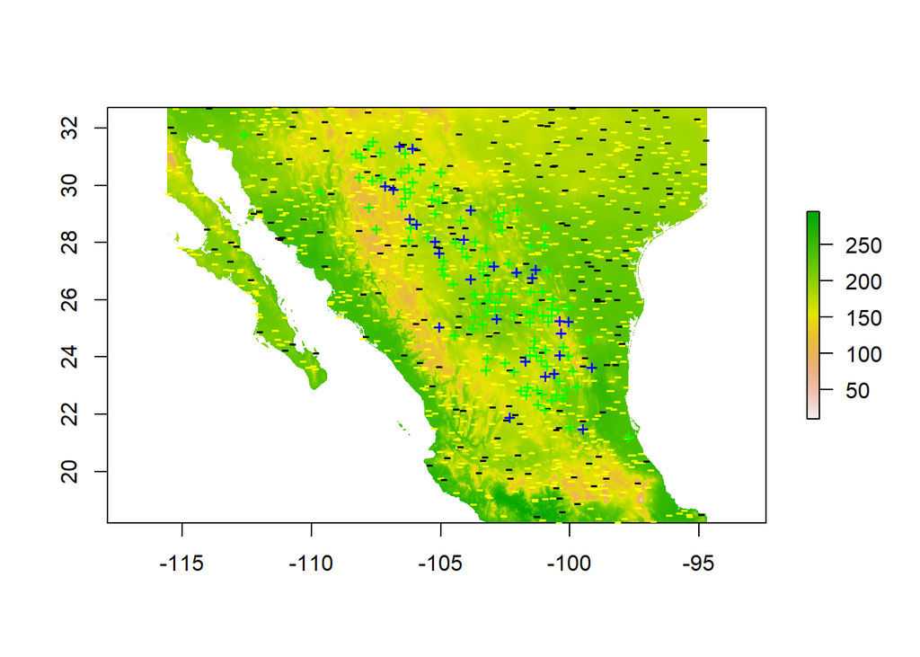

```r
plot(clim.m[[1]])
points(backg_train, pch='-', cex=1, col='yellow')
points(backg_test, pch='-',  cex=1, col='black')
points(pres_train, pch= '+', col='green')
points(pres_test, pch='+', col='blue')
```

Ahora vamos a calibrar con el primer conjunto que extrajimos, pres_train:

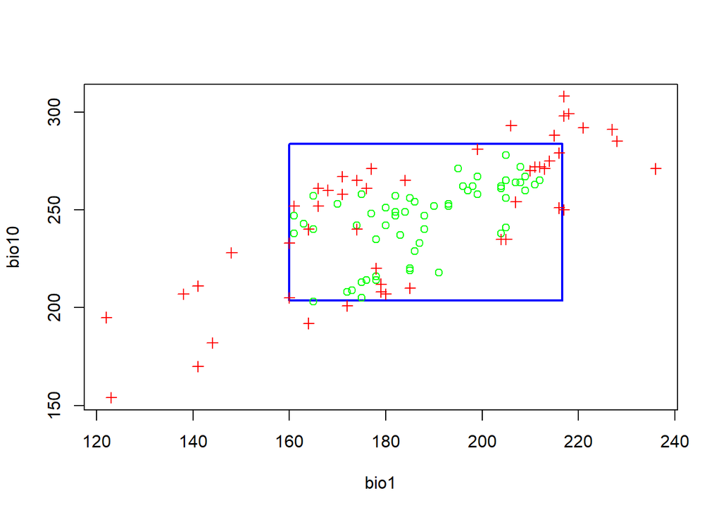

```r
bc <- bioclim(clim.m, pres_train)
plot(bc, a=1, b=2, p=0.85)
```

Vamos a validar nuestro modelo de Bioclim

```r
# Usaremos la función evaluate de dismo.
eval.modesta <- evaluate(pres_test, backg_test, bc, clim.m)
eval.modesta
```

```
## class          : ModelEvaluation
## n presences    : 27
## n absences     : 200
## AUC            : 0.7464815
## cor            : 0.3104916
## max TPR+TNR at : 0.01808182
```

Vamos a calcular un umbral

```r
tr <- threshold(eval.modesta, 'spec_sens')
tr
```

```
## [1] 0.01808182
```

Vamos a hacer la predicción en la geografía:

```r
pred.bioc.v3 <- predict(clim.m, bc, ext=ext, progress='')
pred.bioc.v3
```

```
## class       : RasterLayer
## dimensions  : 1742, 2509, 4370678  (nrow, ncol, ncell)
## resolution  : 0.008333334, 0.008333334  (x, y)
## extent      : -115.61, -94.70169, 18.2046, 32.72126  (xmin, xmax, ymin, ymax)
## coord. ref. : NA
## data source : in memory
## names       : layer
## values      : 0, 0.7272727  (min, max)
```

Graficamos los dos mapas de predicciones, el continuo y el discreto usando el valor de umbral que calculamos antes.

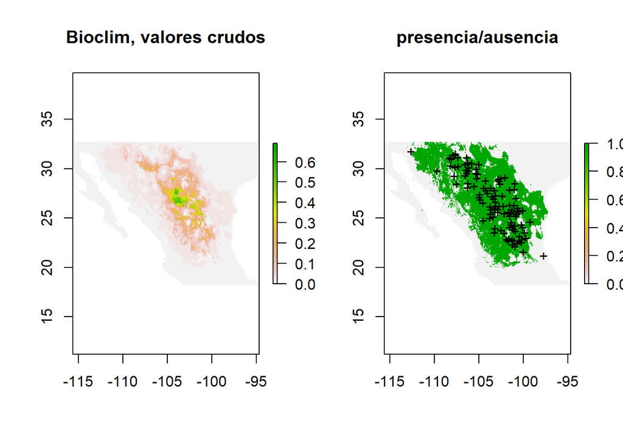

```r
par(mfrow=c(1,2))
plot(pred.bioc.v3, main='Bioclim, valores crudos')
plot(pred.bioc.v3 > tr, main='presencia/ausencia')
points(pres_train, pch='+')
```

Ahora vamos con Maxent, pero en la plataforma dedicada del programa.

Eso es todo!

Escrito por Julián A. Velasco, 29 de Julio de 2018.